# Distribuciones de Probabilidad Continuas con R

Para $P(Y \le 11)-P(Y \le 7)$ escribimos:

```r
punif(q=11, min=5, max=15) - punif(q=7, min=5, max=15)
```

0.4

Para observar $P(7 \le Y \le 11)$ como área bajo la curva de densidad uniforme, utilizamos la función `polygon(x, y,border=NA)` que dibuja polígonos basado en dos vectores de coordenadas `x` y `y`. El argumento `border=NA` determina el color del borde del polígono. Si su valor es `NA`, no se dibuja el borde.

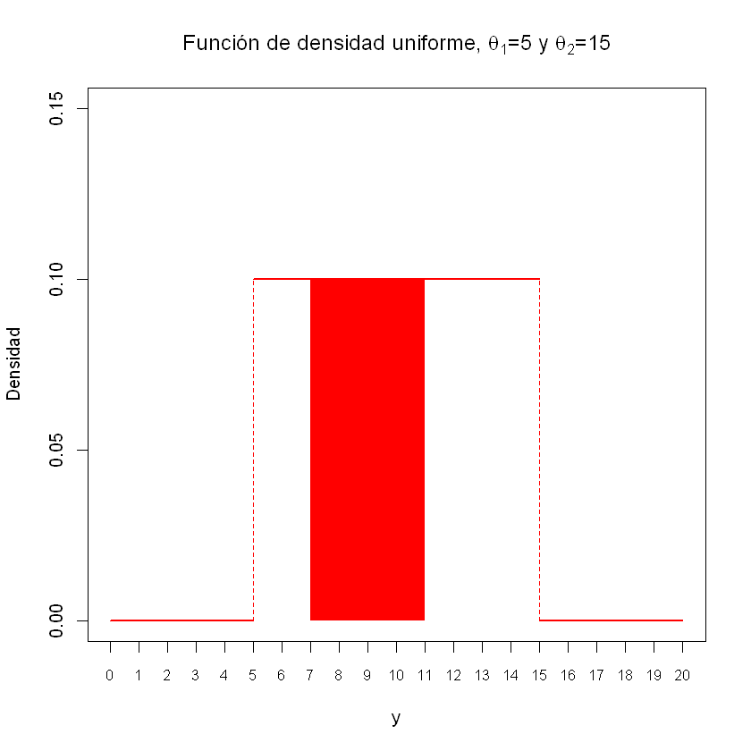

```r
# Densidad Uniforme
plot(y, fy, type="l",col="red",lwd=2,
     xlab="y",ylab="Densidad",
     xlim = c(0,20), ylim = c(0,0.15),
     xaxt="n",
     main= expression(paste("Función de densidad uniforme, ", theta[1], "=5 y ", theta[2],"=15")))

# El eje x se añade manualmente
axis(side = 1, at = 0:20, cex.axis=0.8)

# Para todos los valores que no se encuentran entre 5 y 15
segments(x0=0 ,y0=0,x1=5 ,y1=0,col ="red",lwd = 2)
segments(x0=15,y0=0,x1=20,y1=0,col ="red",lwd = 2)

# Líneas Entrecortadas
segments(x0=5  ,y0=0,x1=5  ,y1=0.1,col ="red",lty=2)
segments(x0=15 ,y0=0,x1=15 ,y1=0.1,col ="red",lty=2)

# Área bajo la curva
x.cord = c(7,   7,  11, 11)
y.cord = c(0, 0.1, 0.1,  0)
polygon(x.cord, y.cord, border=NA, col="red")
```

Observamos que la base del rectángulo es $4$ y la altura $0.1$ por lo que se puede verificar que el área de interés es de $0.4$.

```qunif(p, min = 0, max = 1, lower.tail = TRUE)```

Donde:

- **`p`** es la probabilidad a la izquierda/derecha de $y_0$. Ver `lower.tail`.
- **`min`** corresponde al parámetro $\theta_1$
- **`max`** corresponde al parámetro $\theta_2$
- **`lower.tail`** determina si el valor $y_0$ a devolver, cumple con $P(Y \le y_0)= p$ (si `TRUE`) o $P(Y > y_0)= p$ (si `FALSE` )

Para encontrar el valor $y_0$ que cumple con $P(Y \le y_0)= 0.20$, escribimos:

```r
qunif(p=0.20, min = 5, max = 15, lower.tail = TRUE)
```

7

Comprobamos la respuesta $y_o=7$ con la función de **distribución** `punif()`, buscando la probabilidad $P(Y \le 7)$

```r
punif(7, min = 5, max = 15,lower.tail = TRUE)
```

0.2

Finalmente, podemos generar valores aleatorios de $Y \tilde{} Unif(\theta_1=5,\theta_2=15)$ con la función

```runif(n, min = 0, max = 1)```

Donde:

- **`n`** es el número de datos aleatorios a generar.
- **`min`** corresponde al parámetro $\theta_1$
- **`max`** corresponde al parámetro $\theta_2$

Generamos 1'000.000 de valores aleatorios que siguen la distribución $Unif(\theta_1=5,\theta_2=15)$. Si calculamos la media y la varianza de la simulación, observamos que se aproxima a la esperanza $E(Y)=\frac{\theta_1+\theta_2}{2}=\frac{20}{2}=10$ y varianza $Var(Y)=\frac{(\theta_2-\theta_1)^2}{12}=\frac{100}{12}=8.33$ teóricas.

```r
sim      = runif(1000000, min = 5, max = 15)
mean(sim)
var(sim)
```

9.99933115323165

8.33541170063366

Finalmente, graficamos un histograma de las simulaciones realizadas. Añadimos la función de densidad uniforme en línea roja y observamos que el histograma se ajusta bien a la función de densidad teórica.

El argumento `prob=TRUE` en la función `hist()` sirve para que el eje vertical devuelva valores en t+erminos de la densidad.

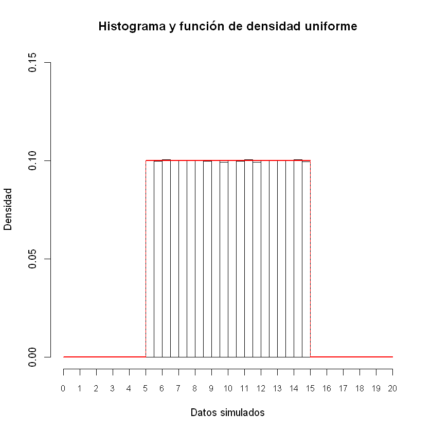

```r
# Histograma
hist(sim, prob=TRUE, breaks=20,
     xlab="Datos simulados",ylab="Densidad",
     xlim = c(0,20), ylim = c(0,0.15),
     xaxt = "n",
     main = "Histograma y función de densidad uniforme")

# El eje x se añade manualmente
axis(side = 1, at = 0:20, cex.axis=0.8)

# Densidad Uniforme
lines(y, fy, type="l",col="red",lwd=2)

# Para todos los valores que no se encuentran entre 5 y 15
segments(x0=0 ,y0=0,x1=5 ,y1=0,col ="red",lwd = 2)
segments(x0=15,y0=0,x1=20,y1=0,col ="red",lwd = 2)

# Líneas Entrecortadas
segments(x0=5  ,y0=0,x1=5  ,y1=0.1,col ="red",lty=2)
segments(x0=15 ,y0=0,x1=15 ,y1=0.1,col ="red",lty=2)
```